# Modelling

Author

Matthew Gordon

Published

May 12, 2026

## Introduction

The dataset consists of 100 patients and includes demographic characteristics such as age, sex, smoking status, and treatment group, as well as 51 genetic single nucleotide polymorphisms (SNPs). There are two outcome variables: Activating Factor (AF), a continuous measure of response, and Positive Response (PR), a binary indicator of treatment effectiveness.

The dataset was obtained from a collaborator and provided via email.

The key variable of interest was the treatment group; A, B or C. We are also interested in the effects of

- Age: the age in years of the participant, ranging from 25 to 45
- Sex: male or female
- SNPs: a set of 51 genetic predictors, recorded as categorical genotype values

The key research question was to assess the effect of treatment group on AF and the probability of a PR, while accounting for demographic characteristics (age, sex) and genetic variation (SNPs).

## Methods

#### Cleaning

The raw dataset was imported from the Excel file FITFR-final-data-v3.xlsx. The first row of the spreadsheet contained the variable names, so this row was promoted to column headers using row_to_names().

The smoker column was removed, as well as the last four rows of the dataset, as they did not contain any useful information.

Illogical age values such as -99 were replaced with NA. The response variable PR was converted “yes”, “no” strings into a binary “1”, “0”.

The sex and treatment columns were standardised to “male”, “female” and “A”, “B”, “C”, so that inconsistent entries didn’t appear as a different chatagory.

Finally, the variables age, ID and AF were converted to numeric format, and the remaining character variables were converted to factors.

This cleaned version of the dataset was saved as clean_data.csv to not override the original dataset and have a consistent version of the data to load for modelling. Upon loading this dataset into RStudio for modelling, the chategorical variables need to be converted back into factors as csv files do not store this structure.

#### EDA

Exploratory data analysis was conducted using a summary Table1 of the dataset and univariate plots of each predictor against the response variables to assess distributions and potential relationships.

|  | A (N=32) | B (N=29) | C (N=39) | Overall (N=100) |
| --- | --- | --- | --- | --- |
| age |  |  |  |  |
| Mean (SD) | 34.3 (6.12) | 36.3 (5.68) | 32.4 (6.34) | 34.2 (6.23) |
| Median [Min, Max] | 33.5 [25.0, 45.0] | 37.0 [25.0, 45.0] | 30.0 [25.0, 45.0] | 34.5 [25.0, 45.0] |
| Missing | 0 (0%) | 1 (3.4%) | 1 (2.6%) | 2 (2.0%) |
| sex |  |  |  |  |
| female | 15 (46.9%) | 17 (58.6%) | 19 (48.7%) | 51 (51.0%) |
| male | 17 (53.1%) | 12 (41.4%) | 20 (51.3%) | 49 (49.0%) |
| AF |  |  |  |  |
| Mean (SD) | 37.5 (6.37) | 76.9 (11.2) | 69.2 (13.0) | 61.3 (19.8) |
| Median [Min, Max] | 36.4 [26.0, 48.0] | 77.8 [53.9, 96.0] | 64.3 [52.8, 95.4] | 61.1 [26.0, 96.0] |

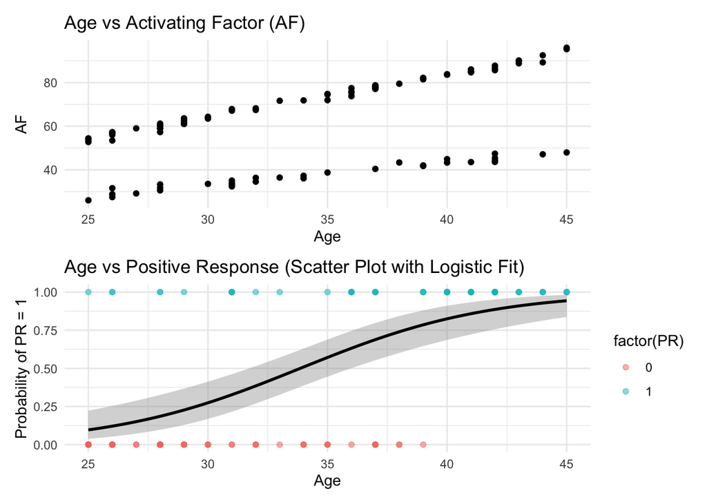

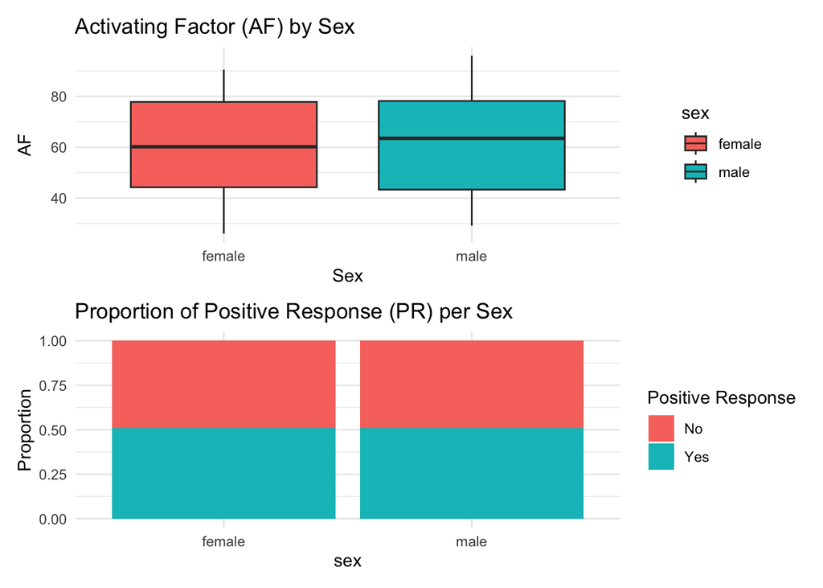

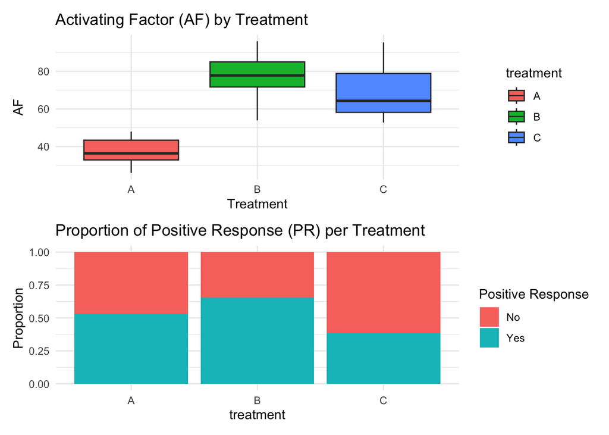

#### Activating Factor (AF) Models

The simple AF model used a linear regression approach to estimate the effect of treatment group and age on AF. An ordinary least squares linear regression was fitted using the “lm” engine by linear_reg(). This model was selected as EDA indicated a linear relationship.

In pre-processing to fit the model, the treatment variable was converted into a dummy variable, since linear regression requires numeric inputs. Treatment group A is used as the reference category and the treatment coefficients represent the differences in AF relative to group A. Age was centred to better interpretability of the model, with the intercept now representing expected AF for the reference treatment group at the average age as opposed to age zero, which is meaningless to us. We split our data into a training set and a test set, using the seed (123) and stratifying over treatment.

The recipe and model were combined into a workflow to ensure that the same preprocessing steps were applied consistently during fitting and prediction. We fit the model using the training data, before generating predictions to assess the performance of the model against the testing data.

This model was extended to add an interaction term between age and treatment group to assess whether the effect of age on AF is different across treatment groups. We used the same model type and engine as the simple AF model, reusing the training and testing split from before.

In pre-processing, missing values in the age data were replaced with the mean age using impute_mean(). We also once again centred the age for interpretability and converted treatment to dummy variables. Finally, interaction terms were added between and each of the treatment dummy variables. The recipe and model were combined in a workflow for consistency across fitting and testing.

We fitted the model with the training data and generated predictions to evaluate performance using the test set. We compared the performance of our two linear regression models by comparing performance metrics, AIC, $R^2$ and adjusted $R^2$, as well as plotting the predicted AF values against the actual AF values. Finally, for a visual representation of the relationship, we plotted a scatter of the AF against age with the slopes from our model to compare. The model assumptions were assessed by the plots generated by the gglm() in the gglm package.

A Lasso model was also considered due to the large number of potential predictors, mainly the SNPs, however it was found that these SNPs had no significant effect so a simpler model was favoured.

#### Positive Response (PR) Models

The PR response variable is binary and thus a logistic regression model was fitted. We started with an initial simple model, with just treatment as a predictor. The logistic regression model was fitted using the “glm” engine via logistic_reg(). The dataset was split into a training and test set with the seed (123).

As with the AF models, missing age values were replaces with the mean age using step_impute_mean(age). Age was then centred for interpretability. Treatment was once again converted to dummy variables. We used predicted probabilities and classes generated from the test data to assess the model fitted on the training data.

A more complex logistic model was fit and predictions were generated reusing the same workflow structure, with the recipe updated to include age as a second predictor. These two models were compared via model performance metrics including accuracy, sensitivity, specificity and ROC AUC to decide if including age improved model prediction. We also generated ROC curves for a visual representation of the predictive power of the models.

In order to determine whether the SNPs had any significance to probability of PR, a series of univariate logistic regression models were generated, with each SNP tested individually against PR. The SNP with no variation was removed as it would not into the model and cannot explain differences in response. The top five SNPs as ranked by by adjusted p-value were summarised in a table. The p-values were adjusted using the false discovery rate method.

## Results

#### AF Model

Table 1: Estimated coefficients from a linear interaction model examining the effects of age, centred at its mean, and treatment on Activating Factor (AF). The intercept represents the expected AF for the reference group, Treatment A, at the mean age. Treatments B and C are associated with large increases in AF relative to Treatment A at the mean age. Age has a positive effect on AF, and the significant interaction terms indicate that the effect of age is stronger under Treatments B and C compared to Treatment A. All predictors are highly statistically significant ($p < 0.001$).

Linear Interaction Model

| term | estimate | std.error | statistic | p.value |
| --- | --- | --- | --- | --- |
| (Intercept) | 37.888 | 0.479 | 79.126 | 1.11 × 10<sup>−68</sup> |
| age | 1.021 | 0.082 | 12.378 | 4.40 × 10<sup>−19</sup> |
| treatment_B | 35.434 | 0.728 | 48.699 | 1.34 × 10<sup>−54</sup> |
| treatment_C | 36.080 | 0.665 | 54.278 | 1.01 × 10<sup>−57</sup> |
| age_x_treatment_B | 0.904 | 0.126 | 7.182 | 6.65 × 10<sup>−10</sup> |
| age_x_treatment_C | 1.023 | 0.107 | 9.546 | 3.53 × 10<sup>−14</sup> |

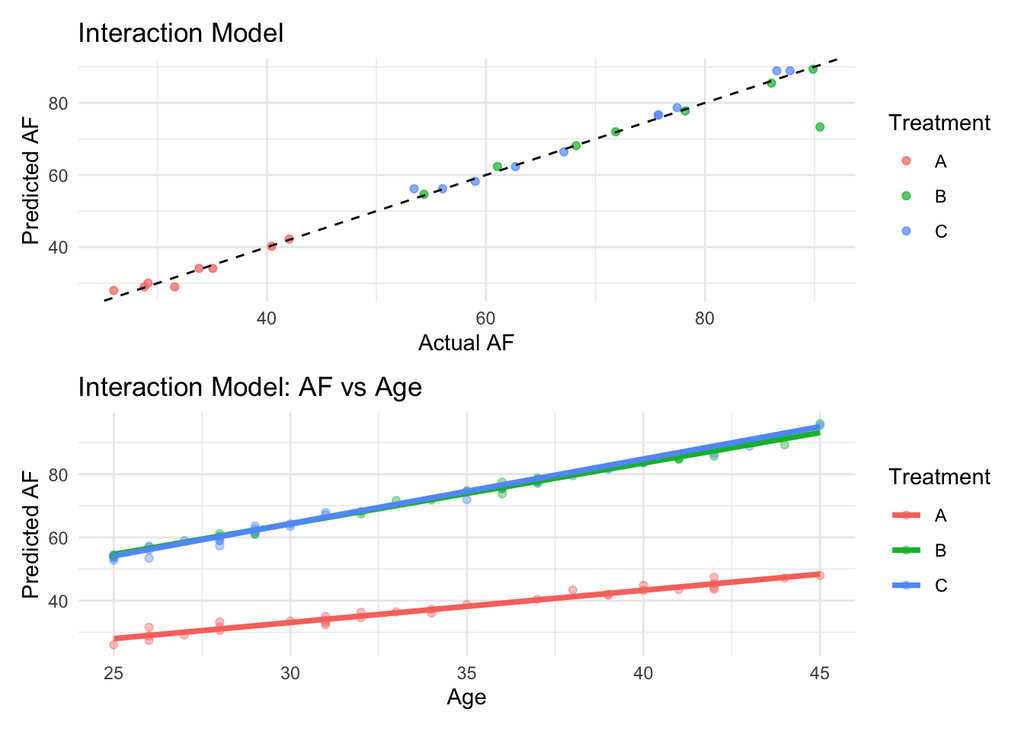

Figure 1: Interaction model results for AF. Predicted values closely match observed values in the top panel, indicating strong model fit. AF increases with age across all treatments in the bottom panel, with larger increases under Treatments B and C, demonstrating an age-by-treatment interaction.

Table 2: Comparison of simple and interaction linear regression models predicting Activating Factor (AF) using centred age and treatment. The interaction model, which includes age-by-treatment terms, demonstrates improved model fit, with a lower AIC and higher $R^2$ and adjusted $R^2$ values compared to the simple model. This indicates that allowing the effect of age to vary across treatment groups provides a better explanation of variation in AF.

Linear Model Comparison

Simple vs Interaction Models

| Model | AIC | R² | Adjusted R² |
| --- | --- | --- | --- |
| Simple Linear Regression | 369.708 | 0.978 | 0.977 |
| Interaction Linear Regression | 341.662 | 0.987 | 0.986 |

#### PR Model

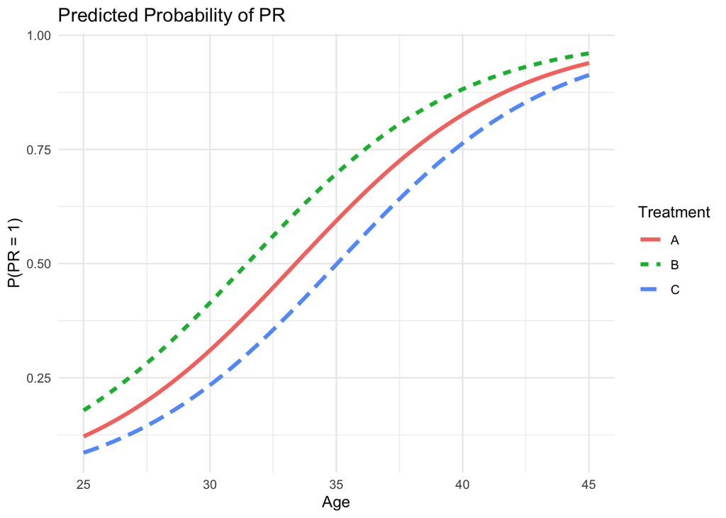

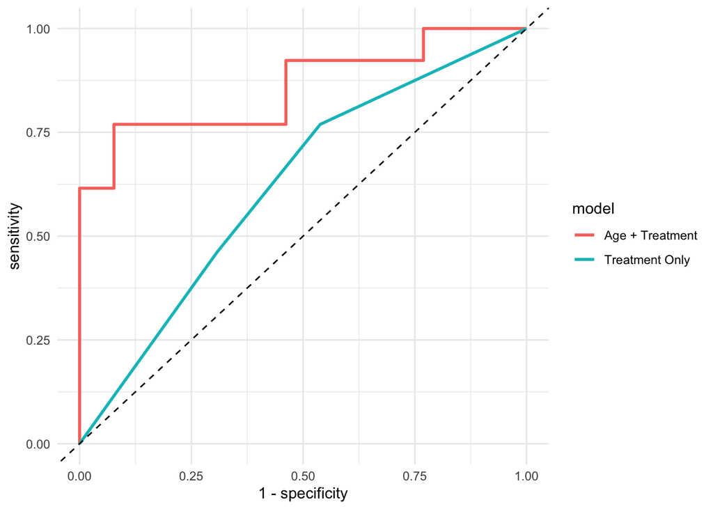

| Model | Accuracy | Sensitivity | Specificity | ROC_AUC |
| --- | --- | --- | --- | --- |
| Age + Treatment | 0.654 | 0.769 | 0.538 | 0.858 |
| Treatment Only | 0.615 | 0.769 | 0.462 | 0.621 |

Top 5 SNPs Associated with Positive Response

Ranked by adjusted p-value

| SNP | Estimate | Std. Error | Z-value | p-value | Adjusted p-value |
| --- | --- | --- | --- | --- | --- |
| rs91154 | −1.638 | 0.649 | −2.524 | 0.012 | 0.657 |
| rs29978 | −1.386 | 0.559 | −2.480 | 0.013 | 0.657 |
| rs21972 | −0.719 | 0.527 | −1.365 | 0.172 | 0.784 |
| rs57179 | 1.163 | 0.544 | 2.139 | 0.032 | 0.784 |
| rs13977 | −0.806 | 0.578 | −1.396 | 0.163 | 0.784 |